# Clustering

### Build The Model

- Support: How frequently the item set appears in the data set.
- Confidence: Indication of how often the rule has been found to be true.
- Lift: How likely Item Y is to be purchased if item X is purchased.

```r
rules <- apriori(asm, parameter = list(supp = 0.005, conf = 0.5))
```

```
## Apriori
##
## Parameter specification:
##  confidence minval smax arem  aval originalSupport maxtime support minlen
##         0.5    0.1    1 none FALSE            TRUE       5   0.005      1
##  maxlen target  ext
##      10  rules TRUE
##
## Algorithmic control:
##  filter tree heap memopt load sort verbose
##     0.1 TRUE TRUE  FALSE TRUE    2    TRUE
##
## Absolute minimum support count: 49
##
## set item appearances ...[0 item(s)] done [0.00s].
## set transactions ...[201 item(s), 9836 transaction(s)] done [0.00s].
## sorting and recoding items ... [120 item(s)] done [0.00s].
## creating transaction tree ... done [0.00s].
## checking subsets of size 1 2 3 4 done [0.00s].
## writing ... [120 rule(s)] done [0.00s].
## creating S4 object  ... done [0.00s].
```

```r
summary(rules)
```

```
## set of 120 rules
##
## rule length distribution (lhs + rhs):sizes
##  2  3  4
##  1 98 21
##
##    Min. 1st Qu.  Median    Mean 3rd Qu.    Max.
##   2.000   3.000   3.000   3.167   3.000   4.000
##
## summary of quality measures:
##     support           confidence        coverage             lift
##  Min.   :0.005083   Min.   :0.5000   Min.   :0.008133   Min.   :1.957
##  1st Qu.:0.005668   1st Qu.:0.5181   1st Qu.:0.010141   1st Qu.:2.092
##  Median :0.006202   Median :0.5445   Median :0.011488   Median :2.249
##  Mean   :0.007343   Mean   :0.5537   Mean   :0.013402   Mean   :2.379
##  3rd Qu.:0.007981   3rd Qu.:0.5762   3rd Qu.:0.014666   3rd Qu.:2.643
##  Max.   :0.022265   Max.   :0.7000   Max.   :0.043412   Max.   :3.691
##      count
##  Min.   : 50.00
##  1st Qu.: 55.75
##  Median : 61.00
##  Mean   : 72.22
##  3rd Qu.: 78.50
##  Max.   :219.00
##
## mining info:
##  data ntransactions support confidence
##   asm          9836   0.005        0.5
##                                                             call
##  apriori(data = asm, parameter = list(supp = 0.005, conf = 0.5))
```

The A-priori Algorithm: The main idea behind this algorithm is that it reduces the number of itemsets we need to examine. By eliminating items by first looking at smaller sets and recognizing that a large set cannot be frequent unless all its subsets are. Simply put if an itemset is infrequent then all of its subsets must also be infrequent. - The algorithm uses the idea of the bread-first search strategy.

### Analyze a Specific Rule

- We want to analyze what items are being bought before yogurt is being bought
- if (Items bought) then yogurt will be bought. so we are looking at the items bought before yogurt.

```r
yogurt_rules <- apriori(asm,
                          parameter = list(supp=0.003, conf=0.5,
                                         maxlen=10,
                                         minlen=2),
                          appearance = list(default="lhs", rhs="yogurt"))
```

```
## Apriori
##
## Parameter specification:
##  confidence minval smax arem  aval originalSupport maxtime support minlen
##         0.5    0.1    1 none FALSE            TRUE       5   0.003      2
##  maxlen target  ext
##      10  rules TRUE
##
## Algorithmic control:
##  filter tree heap memopt load sort verbose
##     0.1 TRUE TRUE  FALSE TRUE    2    TRUE
##
## Absolute minimum support count: 29
##
## set item appearances ...[1 item(s)] done [0.00s].
## set transactions ...[201 item(s), 9836 transaction(s)] done [0.00s].
## sorting and recoding items ... [136 item(s)] done [0.00s].
## creating transaction tree ... done [0.00s].
## checking subsets of size 1 2 3 4 5 done [0.00s].
## writing ... [9 rule(s)] done [0.00s].
## creating S4 object  ... done [0.00s].
```

```r
inspect(yogurt_rules)
```

```
##     lhs                      rhs          support confidence    coverage     lift count
## [1] {cream cheese,
##      whipped/sour cream}  => {yogurt} 0.003355022  0.5238095 0.006405043 3.755241    33
## [2] {cream cheese,
##      root vegetables}     => {yogurt} 0.003761692  0.5000000 0.007523383 3.584548    37
## [3] {curd,
##      tropical fruit}      => {yogurt} 0.005286702  0.5148515 0.010268402 3.691020    52
## [4] {cream cheese,
##      other vegetables,
##      whole milk}          => {yogurt} 0.003456690  0.5151515 0.006710045 3.693171    34
## [5] {curd,
##      tropical fruit,
##      whole milk}          => {yogurt} 0.003965026  0.6093750 0.006506710 4.368668    39
## [6] {butter,
##      other vegetables,
##      tropical fruit}      => {yogurt} 0.003050020  0.5555556 0.005490037 3.982831    30
## [7] {butter,
##      tropical fruit,
##      whole milk}          => {yogurt} 0.003355022  0.5409836 0.006201708 3.878364    33
## [8] {tropical fruit,
##      whipped/sour cream,
##      whole milk}          => {yogurt} 0.004371696  0.5512821 0.007930053 3.952194    43
## [9] {other vegetables,
##      root vegetables,
##      tropical fruit,
##      whole milk}          => {yogurt} 0.003558357  0.5072464 0.007015047 3.636498    35
```

### Display Quantitative and Visual Results

```r
rules_conf <- sort(rules, by="confidence", decreasing = TRUE) ## Shows rules with the highest confidence
head(inspect(rules_conf))
```

```
##       lhs                            rhs                    support confidence    coverage     lift count
## [1]   {root vegetables,
##        tropical fruit,
##        yogurt}                    => {whole milk}       0.005693371  0.7000000 0.008133388 2.739833    56
## [2]   {other vegetables,
##        pip fruit,
##        root vegetables}           => {whole milk}       0.005490037  0.6750000 0.008133388 2.641982    54
## [3]   {butter,
##        whipped/sour cream}        => {whole milk}       0.006710045  0.6600000 0.010166734 2.583271    66
## [4]   {pip fruit,
##        whipped/sour cream}        => {whole milk}       0.005998373  0.6483516 0.009251728 2.537679    59
## [5]   {butter,
##        yogurt}                    => {whole milk}       0.009353396  0.6388889 0.014640098 2.500641    92
## [6]   {butter,
##        root vegetables}           => {whole milk}       0.008235055  0.6377953 0.012911753 2.496361    81
## [7]   {curd,
##        tropical fruit}            => {whole milk}       0.006506710  0.6336634 0.010268402 2.480188    64
## [8]   {citrus fruit,
##        root vegetables,
##        whole milk}                => {other vegetables} 0.005795039  0.6333333 0.009150061 3.273498    57
## [9]   {other vegetables,
##        pip fruit,
##        yogurt}                    => {whole milk}       0.005083367  0.6250000 0.008133388 2.446279    50
## [10]  {domestic eggs,
##        pip fruit}                 => {whole milk}       0.005388369  0.6235294 0.008641724 2.440523    53
## [11]  {butter,
##        tropical fruit}            => {whole milk}       0.006201708  0.6224490 0.009963400 2.436295    61
## [12]  {domestic eggs,
##        margarine}                 => {whole milk}       0.005185035  0.6219512 0.008336722 2.434346    51
## [13]  {butter,
##        domestic eggs}             => {whole milk}       0.005998373  0.6210526 0.009658398 2.430829    59
## [14]  {other vegetables,
##        tropical fruit,
##        yogurt}                    => {whole milk}       0.007625051  0.6198347 0.012301749 2.426062    75
## [15]  {fruit/vegetable juice,
##        other vegetables,
##        yogurt}                    => {whole milk}       0.005083367  0.6172840 0.008235055 2.416078    50
## [16]  {pip fruit,
##        root vegetables,
##        whole milk}                => {other vegetables} 0.005490037  0.6136364 0.008946726 3.171691    54
```

[output cut: 206 more lines]

```
##        root vegetables}           => {other vegetables} 0.012200081  0.5020921 0.024298495 2.595154   120
## [114] {frozen vegetables,
##        rolls/buns}                => {whole milk}       0.005083367  0.5000000 0.010166734 1.957023    50
## [115] {beef,
##        rolls/buns}                => {whole milk}       0.006811712  0.5000000 0.013623424 1.957023    67
## [116] {pork,
##        root vegetables}           => {whole milk}       0.006811712  0.5000000 0.013623424 1.957023    67
## [117] {frankfurter,
##        root vegetables}           => {whole milk}       0.005083367  0.5000000 0.010166734 1.957023    50
## [118] {brown bread,
##        other vegetables}          => {whole milk}       0.009353396  0.5000000 0.018706791 1.957023    92
## [119] {root vegetables,
##        whipped/sour cream}        => {other vegetables} 0.008540057  0.5000000 0.017080114 2.584341    84
## [120] {root vegetables,
##        yogurt}                    => {other vegetables} 0.012911753  0.5000000 0.025823505 2.584341   127
```

```r
rules_lift <- sort(rules, by="lift", decreasing = TRUE) ## Shows rules with the highest Lift
head(inspect(rules_lift))
```

```
##       lhs                            rhs                    support confidence    coverage     lift count
## [1]   {curd,
##        tropical fruit}            => {yogurt}           0.005286702  0.5148515 0.010268402 3.691020    52
## [2]   {citrus fruit,
##        root vegetables,
##        whole milk}                => {other vegetables} 0.005795039  0.6333333 0.009150061 3.273498    57
## [3]   {pip fruit,
##        root vegetables,
##        whole milk}                => {other vegetables} 0.005490037  0.6136364 0.008946726 3.171691    54
## [4]   {pip fruit,
##        whipped/sour cream}        => {other vegetables} 0.005591704  0.6043956 0.009251728 3.123928    55
## [5]   {onions,
##        root vegetables}           => {other vegetables} 0.005693371  0.6021505 0.009455063 3.112324    56
## [6]   {citrus fruit,
##        root vegetables}           => {other vegetables} 0.010370069  0.5862069 0.017690118 3.029916   102
## [7]   {root vegetables,
##        tropical fruit,
##        whole milk}                => {other vegetables} 0.007015047  0.5847458 0.011996747 3.022364    69
## [8]   {root vegetables,
##        tropical fruit}            => {other vegetables} 0.012301749  0.5845411 0.021045140 3.021306   121
## [9]   {butter,
##        whipped/sour cream}        => {other vegetables} 0.005795039  0.5700000 0.010166734 2.946148    57
## [10]  {tropical fruit,
##        whipped/sour cream}        => {other vegetables} 0.007828386  0.5661765 0.013826759 2.926386    77
## [11]  {butter,
##        tropical fruit}            => {other vegetables} 0.005490037  0.5510204 0.009963400 2.848049    54
## [12]  {fruit/vegetable juice,
##        root vegetables}           => {other vegetables} 0.006608377  0.5508475 0.011996747 2.847155    65
## [13]  {root vegetables,
##        whipped/sour cream,
##        whole milk}                => {other vegetables} 0.005185035  0.5483871 0.009455063 2.834438    51
## [14]  {onions,
##        whole milk}                => {other vegetables} 0.006608377  0.5462185 0.012098414 2.823229    65
## [15]  {root vegetables,
##        whole milk,
##        yogurt}                    => {other vegetables} 0.007828386  0.5384615 0.014538430 2.783136    77
## [16]  {fruit/vegetable juice,
##        whole milk,
##        yogurt}                    => {other vegetables} 0.005083367  0.5376344 0.009455063 2.778861    50
## [17]  {pastry,
```

[output cut: 206 more lines]

```
##        whipped/sour cream}        => {whole milk}       0.014640098  0.5070423 0.028873526 1.984587   144
## [114] {fruit/vegetable juice,
##        yogurt}                    => {whole milk}       0.009455063  0.5054348 0.018706791 1.978295    93
## [115] {newspapers,
##        root vegetables}           => {whole milk}       0.005795039  0.5044248 0.011488410 1.974342    57
## [116] {frozen vegetables,
##        rolls/buns}                => {whole milk}       0.005083367  0.5000000 0.010166734 1.957023    50
## [117] {beef,
##        rolls/buns}                => {whole milk}       0.006811712  0.5000000 0.013623424 1.957023    67
## [118] {pork,
##        root vegetables}           => {whole milk}       0.006811712  0.5000000 0.013623424 1.957023    67
## [119] {frankfurter,
##        root vegetables}           => {whole milk}       0.005083367  0.5000000 0.010166734 1.957023    50
## [120] {brown bread,
##        other vegetables}          => {whole milk}       0.009353396  0.5000000 0.018706791 1.957023    92
```

```
## To reduce overplotting, jitter is added! Use jitter = 0 to prevent jitter.
```

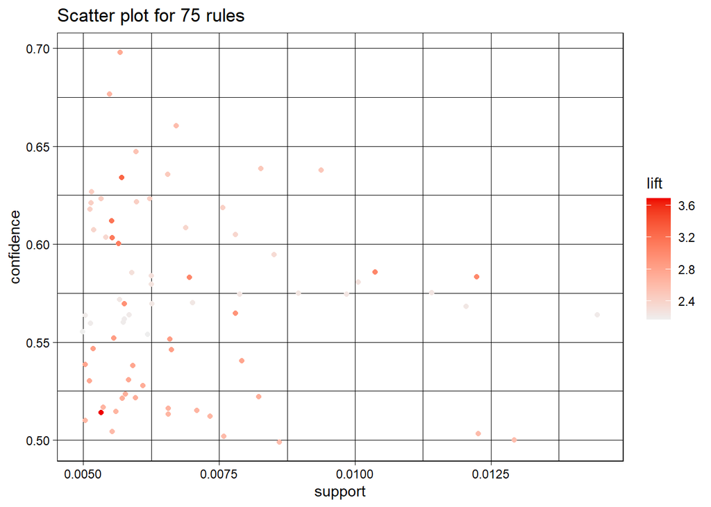

```r
plot(rules, limit = 75) # displays a scatter plot of the first 75 rules with their confidence and suport
```

### Display Graph plot

- For Rules, The LHS items are connected with arrows pointing to the vertex representing the rule and RHS has an arrow pointing to the item.

```r
subrules <- head(rules, n = 10, by = "confidence")

plot(subrules, method = "graph", engine = "htmlwidget") # displays associations between selected items
```

[interactive chart not shown]

### Display Parallel coordinate Plot

- Represents the rules as a parallel coordinate plot. (Shoes rules from LHS to RHS)

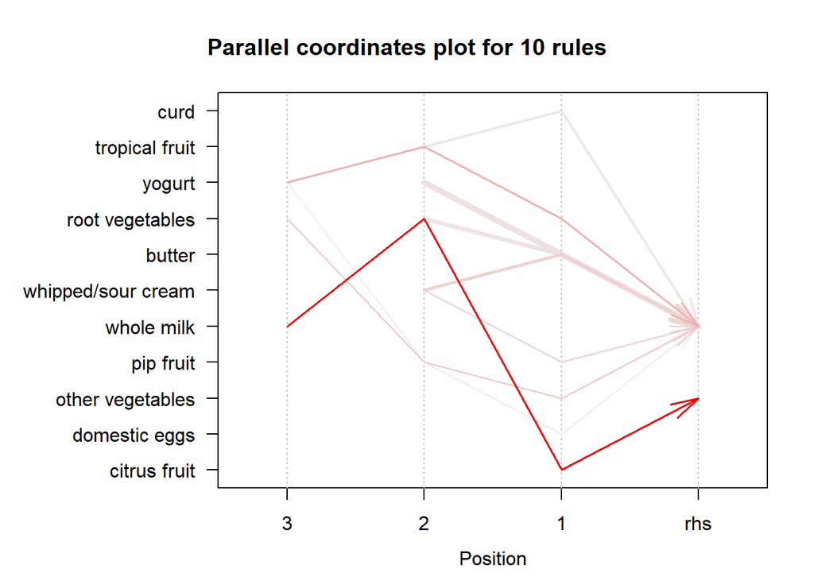

```r
plot(subrules, method = "paracoord", limit = 10) #shows the 10 most common rules and what i
```

## References

https://www.statology.org/k-means-clustering-in-r/ https://towardsdatascience.com/association-rule-mining-in-r-ddf2d044ae50 http://r-statistics.co/Association-Mining-With-R.html https://www.techtarget.com/searchbusinessanalytics/definition/association-rules-in-data-mining